# Session 1 — Exploring the Yogurt Dataset (Group A)

## Overview

This document loads and explores all four CSV files in the **yogurt study** dataset (`data/group_a_yogurt/`). For each file we’ll show:

- What **one row** represents (the unit of observation)
- What **every column** means
- A quick glance at the data

```r
library(tidyverse)
```

## 00 — Sample IDs (`00_sample_ids_yogurt.csv`)

```r
sample_ids <- read_csv("../data/group_a_yogurt/00_sample_ids_yogurt.csv")
glimpse(sample_ids)
```

```
Rows: 102
Columns: 4
$ pid        <chr> "pid_25", "pid_51", "pid_33", "pid_13", "pid_37", "pid_09",…
$ time_point <chr> "baseline", "baseline", "baseline", "baseline", "after_anti…
$ arm        <chr> "unchanged_diet", "yogurt", "yogurt", "yogurt", "unchanged_…
$ sample_id  <chr> "UNCH001", "YOG002", "YOG003", "YOG004", "UNCH005", "UNCH00…
```

**What one row represents:**  
A single biological sample taken from one participant at one time point.

**Column guide:**

| Column | Type | Meaning |
| --- | --- | --- |
| `pid` | identifier | Participant ID. Links to `01_participant_metadata_yogurt.csv`. |
| `time_point` | categorical | When the sample was taken — `baseline` (before antibiotics) or `after_antibiotic` (after a course of antibiotics). |
| `arm` | categorical | Study arm — `yogurt` (ate yogurt during antibiotics) or `unchanged_diet` (no yogurt, normal diet). |
| `sample_id` | identifier | Unique sample code (e.g. `UNCH001` or `YOG002`). Links to qPCR and luminex tables. |

```r
sample_ids |>
  count(arm, time_point) |>
  knitr::kable(col.names = c("Arm", "Time Point", "n"))
```

| Arm | Time Point | n |
| --- | --- | --- |
| unchanged_diet | after_antibiotic | 25 |
| unchanged_diet | baseline | 25 |
| yogurt | after_antibiotic | 26 |
| yogurt | baseline | 26 |

## 01 — Participant Metadata (`01_participant_metadata_yogurt.csv`)

```r
metadata <- read_csv("../data/group_a_yogurt/01_participant_metadata_yogurt.csv")
glimpse(metadata)
```

```
Rows: 51
Columns: 7
$ pid                 <chr> "pid_01", "pid_02", "pid_03", "pid_04", "pid_05", …
$ arm                 <chr> "unchanged_diet", "unchanged_diet", "unchanged_die…
$ days_since_last_sex <dbl> 2, 4, 3, 1, 5, 9, 3, 4, 10, 7, 9, 20, 1, 1, 11, 3,…
$ birth_control       <chr> "no hormonal birth control", "Depoprovera", "no ho…
$ age                 <dbl> 28, 34, 32, 30, 34, 27, 25, 26, 34, 32, 32, 32, 30…
$ education           <chr> "grade 10-12, not matriculated", "less than grade …
$ sex                 <chr> "female", "female", "female", "female", "female", …
```

**What one row represents:**  
One study participant (51 participants total).

**Column guide:**

| Column | Type | Meaning |
| --- | --- | --- |
| `pid` | identifier | Participant ID. Links to `00_sample_ids_yogurt.csv`. |
| `arm` | categorical | Study arm — `yogurt` or `unchanged_diet`. |
| `days_since_last_sex` | numeric | Days since the participant last had sex (range 1–48). |
| `birth_control` | categorical | Birth control method — `Depoprovera` (injectable contraceptive) or `no hormonal birth control`. |
| `age` | numeric | Age in years (range 24–37). |
| `education` | categorical | Highest education level — `less than grade 9`, `grade 10-12, not matriculated`, `grade 10-12, matriculated`, or `post-secondary`. |
| `sex` | categorical | All participants are `female`. |

```r
metadata |>
  count(arm, birth_control) |>
  knitr::kable(col.names = c("Arm", "Birth Control", "n"))
```

| Arm | Birth Control | n |
| --- | --- | --- |
| unchanged_diet | Depoprovera | 8 |
| unchanged_diet | no hormonal birth control | 17 |
| yogurt | Depoprovera | 17 |
| yogurt | no hormonal birth control | 9 |

```r
metadata |>
  summarise(
    n = n(),
    mean_age = mean(age),
    min_age = min(age),
    max_age = max(age)
  )
```

```
# A tibble: 1 × 4
      n mean_age min_age max_age
  <int>    <dbl>   <dbl>   <dbl>
1    51     30.7      24      37
```

## 02 — qPCR Results (`02_qpcr_results_yogurt.csv`)

```r
qpcr <- read_csv("../data/group_a_yogurt/02_qpcr_results_yogurt.csv")
glimpse(qpcr)
```

```
Rows: 102
Columns: 4
$ sample_id      <chr> "UNCH092", "UNCH042", "UNCH015", "UNCH035", "UNCH019", …
$ qpcr_bacteria  <dbl> 3093064.20, 8275.04, 7532202.40, 4794320.40, 5328343.60…
$ qpcr_crispatus <dbl> 0.000, 0.000, 0.000, 12.994, 0.000, 0.000, 0.000, 38.58…
$ qpcr_iners     <dbl> 26.840, 76.040, 554.964, 204308.968, 107806.148, 121045…
```

**What one row represents:**  
Quantitative PCR (qPCR) measurements of bacterial DNA from one vaginal swab sample (102 samples total — one row per sample).

**Column guide:**

| Column | Type | Meaning |
| --- | --- | --- |
| `sample_id` | identifier | Links to `00_sample_ids_yogurt.csv`. |
| `qpcr_bacteria` | numeric | Total bacterial load (16S rRNA gene copies). |
| `qpcr_crispatus` | numeric | Amount of *Lactobacillus crispatus* DNA — a “good” bacterium that helps protect against infections. |
| `qpcr_iners` | numeric | Amount of *Lactobacillus iners* DNA — another *Lactobacillus* species, but less protective than *L. crispatus*. |

```r
# Quick look at the range of bacterial loads
qpcr |>
  summarise(
    min_bacteria = min(qpcr_bacteria),
    median_bacteria = median(qpcr_bacteria),
    max_bacteria = max(qpcr_bacteria),
    pct_detectable_crispatus = mean(qpcr_crispatus > 0) * 100,
    pct_detectable_iners = mean(qpcr_iners > 0) * 100
  ) |>
  knitr::kable(digits = 1)
```

| min_bacteria | median_bacteria | max_bacteria | pct_detectable_crispatus | pct_detectable_iners |
| --- | --- | --- | --- | --- |
| 4251.7 | 2236996 | 126400280 | 35.3 | 92.2 |

## 03 — Luminex Cytokine Results (`03_luminex_results_yogurt.csv`)

```r
luminex <- read_csv("../data/group_a_yogurt/03_luminex_results_yogurt.csv")
glimpse(luminex)
```

```
Rows: 1,020
Columns: 4
$ sample_id <chr> "UNCH092", "UNCH092", "UNCH092", "UNCH092", "UNCH092", "UNCH…
$ cytokine  <chr> "IL-1a", "IL-10", "IL-1b", "IL-8", "IL-6", "TNFa", "IP-10", …
$ conc      <dbl> 5.8500, 0.7670, 0.2505, 7.9200, 0.0935, 0.4710, 177.3800, 36…
$ limits    <chr> "within limits", "out of range", "out of range", "within lim…
```

```r
n_distinct(luminex$sample_id)  # how many unique samples
```

```
[1] 102
```

**What one row represents:**  
One cytokine measurement from one sample. The data is in “long” format — every sample has 10 rows, one per cytokine. (102 samples × 10 cytokines = 1,020 rows.)

**Column guide:**

| Column | Type | Meaning |
| --- | --- | --- |
| `sample_id` | identifier | Links to `00_sample_ids_yogurt.csv`. |
| `cytokine` | categorical | Immune signalling protein measured: IL-1a, IL-1b, IL-6, IL-8, IL-10, TNFa, IFNg (listed as `IFN-Y`), IP-10, MIG, MIP-3a. |
| `conc` | numeric | Concentration of the cytokine (pg/mL). |
| `limits` | categorical | Reliability flag — `within limits` (reliable reading) or `out of range` (concentration too low or too high for the assay to measure accurately). |

```r
# Which cytokines are measured
luminex |>
  count(cytokine) |>
  knitr::kable()
```

| cytokine | n |
| --- | --- |
| IFN-Y | 102 |
| IL-10 | 102 |
| IL-1a | 102 |
| IL-1b | 102 |
| IL-6 | 102 |
| IL-8 | 102 |
| IP-10 | 102 |
| MIG | 102 |
| MIP-3a | 102 |
| TNFa | 102 |

```r
# Proportion of out-of-range results per cytokine
luminex |>
  mutate(flagged = limits != "within limits") |>
  group_by(cytokine) |>
  summarise(pct_flagged = mean(flagged) * 100) |>
  arrange(desc(pct_flagged)) |>
  knitr::kable(digits = 1)
```

| cytokine | pct_flagged |
| --- | --- |
| IL-10 | 100.0 |
| IFN-Y | 99.0 |
| TNFa | 98.0 |
| IL-6 | 75.5 |
| IL-1b | 72.5 |
| MIP-3a | 23.5 |
| MIG | 12.7 |
| IL-8 | 3.9 |
| IP-10 | 2.9 |
| IL-1a | 0.0 |

## How the tables link together

All four tables are linked through **key columns**:

```
01_participant_metadata  ─── pid ───→ 00_sample_ids
                                            │
                                     sample_id
                                        ├──→ 02_qpcr_results    (1 row per sample)
                                        └──→ 03_luminex_results (10 rows per sample)
```

- `01_participant_metadata` ← `pid` → `00_sample_ids`  
  (one participant ↔︎ multiple samples: baseline + after antibiotic)
- `00_sample_ids` ← `sample_id` → `02_qpcr_results`  
  (one sample ↔︎ one qPCR row)
- `00_sample_ids` ← `sample_id` → `03_luminex_results`  
  (one sample ↔︎ 10 cytokine rows)

```r
# Join all three data tables together for a complete picture
qpcr_with_metadata <- qpcr |>
  left_join(sample_ids, by = "sample_id") |>
  left_join(metadata, by = "pid", suffix = c(".sample", "")) |>
  select(sample_id, pid, time_point, arm, everything())

qpcr_with_metadata |>
  count(arm, time_point) |>
  knitr::kable()
```

| arm | time_point | n |
| --- | --- | --- |
| unchanged_diet | after_antibiotic | 25 |
| unchanged_diet | baseline | 25 |
| yogurt | after_antibiotic | 26 |
| yogurt | baseline | 26 |

### Arm vs. time point — total bacterial load

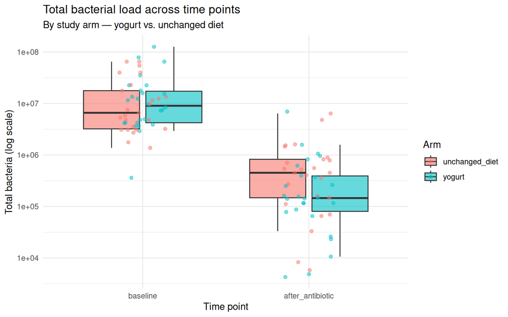

```r
qpcr_with_metadata <- qpcr_with_metadata |>
  mutate(time_point = fct_relevel(time_point, "baseline", "after_antibiotic"))

# Total bacteria across time points, by study arm
qpcr_with_metadata |>
  ggplot(aes(x = time_point, y = qpcr_bacteria, fill = arm)) +
  geom_boxplot(alpha = 0.6, outlier.shape = NA) +
  geom_jitter(aes(color = arm), width = 0.15, alpha = 0.5) +
  scale_y_log10() +
  labs(
    title = "Total bacterial load across time points",
    subtitle = "By study arm — yogurt vs. unchanged diet",
    x = "Time point",
    y = "Total bacteria (log scale)",
    fill = "Arm",
    color = "Arm"
  ) +
  theme_minimal()
```

### L. crispatus vs. L. iners — which species dominates?

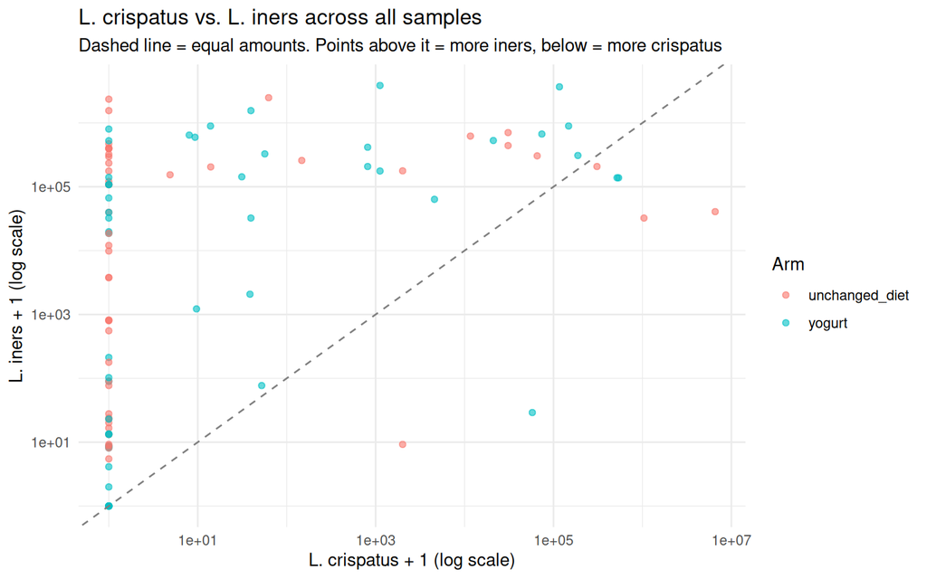

```r
# Add a small constant so we can plot zeros on a log scale
qpcr_with_metadata |>
  ggplot(aes(x = qpcr_crispatus + 1, y = qpcr_iners + 1, color = arm)) +
  geom_point(alpha = 0.6) +
  scale_x_log10() +
  scale_y_log10() +
  geom_abline(slope = 1, linetype = "dashed", color = "grey50") +
  labs(
    title = "L. crispatus vs. L. iners across all samples",
    subtitle = "Dashed line = equal amounts. Points above it = more iners, below = more crispatus",
    x = "L. crispatus + 1 (log scale)",
    y = "L. iners + 1 (log scale)",
    color = "Arm"
  ) +
  theme_minimal()
```

### Key cytokine — IL-1a across time points

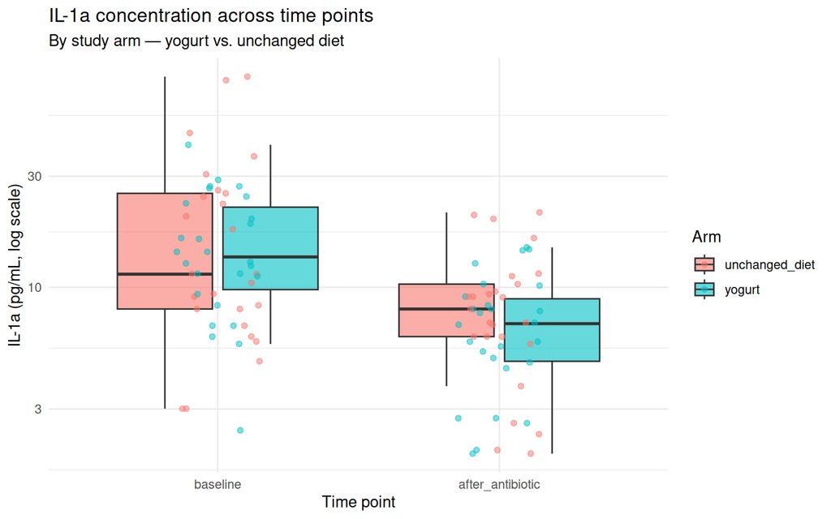

```r
# Join luminex data and pick IL-1a
luminex_plot <- luminex |>
  filter(cytokine == "IL-1a") |>
  left_join(sample_ids, by = "sample_id") |>
  left_join(metadata, by = "pid", suffix = c(".sample", "")) |>
  mutate(time_point = fct_relevel(time_point, "baseline", "after_antibiotic"))

luminex_plot |>
  ggplot(aes(x = time_point, y = conc, fill = arm)) +
  geom_boxplot(alpha = 0.6, outlier.shape = NA) +
  geom_jitter(aes(color = arm), width = 0.15, alpha = 0.5) +
  scale_y_log10() +
  labs(
    title = "IL-1a concentration across time points",
    subtitle = "By study arm — yogurt vs. unchanged diet",
    x = "Time point",
    y = "IL-1a (pg/mL, log scale)",
    fill = "Arm",
    color = "Arm"
  ) +
  theme_minimal()
```

## Quick notes

- **Study design:** This is a longitudinal study following 51 participants at 2 time points — `baseline` (before antibiotics) and `after_antibiotic`. Half ate yogurt during their antibiotic course, the other half kept their normal diet.
- **Why yogurt?** The study is testing whether eating yogurt (which contains live bacteria) helps restore a healthy vaginal microbiome after antibiotics disrupt it.
- **qPCR targets:** The study measures *Lactobacillus crispatus* (a “good” species that produces protective lactic acid) and *Lactobacillus iners* (a related species that’s less protective). Many samples have zero *L. crispatus* — it was undetectable.
- **Birth control:** About half the participants use Depoprovera (an injectable hormonal contraceptive), which can affect the vaginal microbiome.
- **Missing / flagged data:** Luminex has `out of range` flags. Some cytokines (like IL-10, TNFa) are frequently out of range, meaning they’re too low to measure reliably in many samples.
- **Things we don’t know yet:** What specific antibiotic was given? For how long? How much yogurt did the yogurt group eat? Were there any side effects?